# R Notebook

## Objective

In this project we will deal with exploratory analysis, where the objective is to understand how the data is distributed and generate insight for future decision-making, this analysis aims to explore as much as possible the data in a simple, intuitive and informative way. The data used in this project contains information only from 1980 to 2016.

## About Dataset

Columns :

- Name - The names of games
- Platform - Gaming device used for playing
- Year - Year of the game release
- Genre - Genre of the game
- Publisher - Publisher name
- NA_Sales - North America Sales (in millions)
- EU_Sales - Europe Sales (in millions)
- JP_Sales - Japan Sales (in millions)
- Other_Sales - Other countries sales (in millions)
- Global_Sales - Sales over the world (in millions)

|  | Name | Platform | Year | Genre | Publisher | NA_Sales | EU_Sales | JP_Sales | Other_Sales | Global_Sales |
| --- | --- | --- | --- | --- | --- | --- | --- | --- | --- | --- |
| 1 | Wii Sports | Wii | 2006 | Sports | Nintendo | 41.49 | 29.02 | 3.77 | 8.46 | 82.74 |
| 2 | Super Mario Bros. | NES | 1985 | Platform | Nintendo | 29.08 | 3.58 | 6.81 | 0.77 | 40.24 |
| 3 | Mario Kart Wii | Wii | 2008 | Racing | Nintendo | 15.85 | 12.88 | 3.79 | 3.31 | 35.82 |
| 4 | Wii Sports Resort | Wii | 2009 | Sports | Nintendo | 15.75 | 11.01 | 3.28 | 2.96 | 33 |
| 5 | Pokemon Red/Pokemon Blue | GB | 1996 | Role-Playing | Nintendo | 11.27 | 8.89 | 10.22 | 1 | 31.37 |
| 6 | Tetris | GB | 1989 | Puzzle | Nintendo | 23.2 | 2.26 | 4.22 | 0.58 | 30.26 |

```r
summary(data)
```

```
     Name             Platform              Year         Genre
 Length:16323       Length:16323       2009   :1431   Length:16323
 Class :character   Class :character   2008   :1428   Class :character
 Mode  :character   Mode  :character   2010   :1259   Mode  :character
                                       2007   :1202
                                       2011   :1139
                                       2006   :1008
                                       (Other):8856
  Publisher            NA_Sales          EU_Sales          JP_Sales
 Length:16323       Min.   : 0.0000   Min.   : 0.0000   Min.   : 0.00000
 Class :character   1st Qu.: 0.0000   1st Qu.: 0.0000   1st Qu.: 0.00000
 Mode  :character   Median : 0.0800   Median : 0.0200   Median : 0.00000
                    Mean   : 0.2655   Mean   : 0.1476   Mean   : 0.07868
                    3rd Qu.: 0.2400   3rd Qu.: 0.1100   3rd Qu.: 0.04000
                    Max.   :41.4900   Max.   :29.0200   Max.   :10.22000

  Other_Sales        Global_Sales
 Min.   : 0.00000   Min.   : 0.0100
 1st Qu.: 0.00000   1st Qu.: 0.0600
 Median : 0.01000   Median : 0.1700
 Mean   : 0.04834   Mean   : 0.5403
 3rd Qu.: 0.04000   3rd Qu.: 0.4800
 Max.   :10.57000   Max.   :82.7400
```

## These are the most 10 frequent years where sales were high.

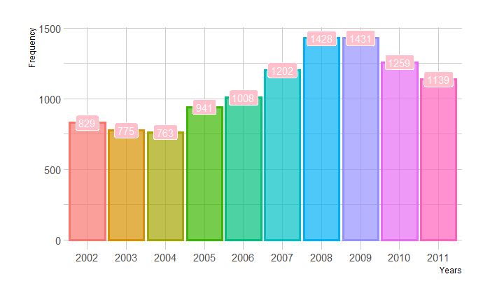

## These are the least 10 years where sales were low.

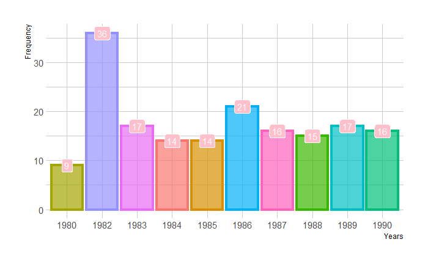

# North American Sales Histogram (in millions)

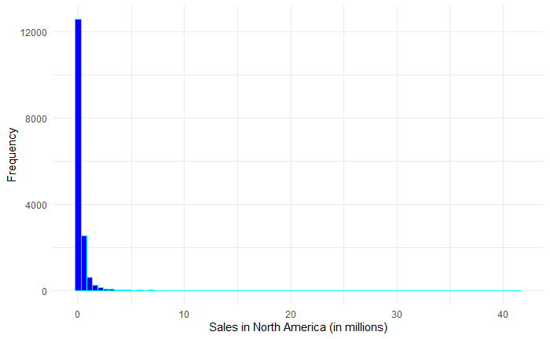

## North American Sales < 2 millions

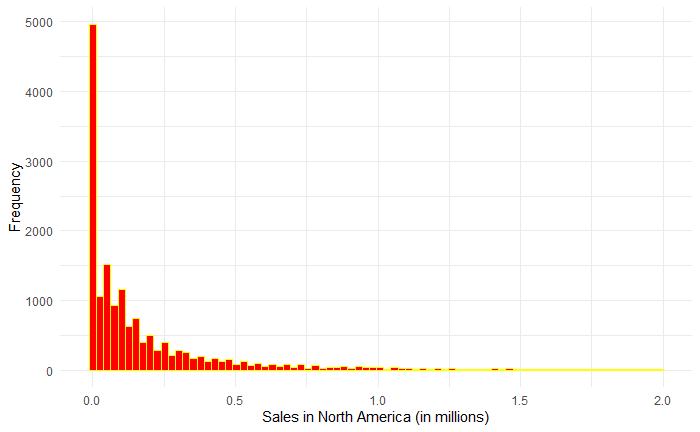

## Europe Sales Histogram (in millions)

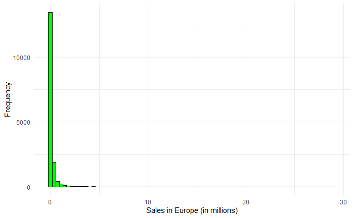

## Europe Sales < 2 millions

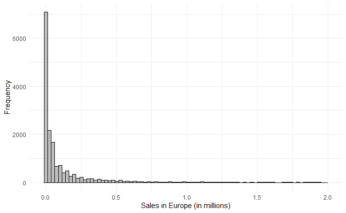

## Frequency Distribution of Games

### Need for Speed:Most Wanted is most frequently distributed game among the whole world

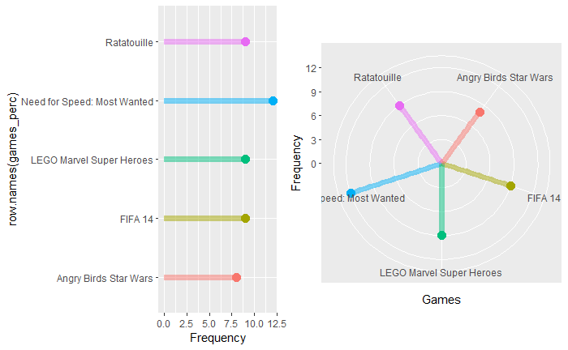

## Frequency distribution of Gaming Platform

### PS2(PlayStation) and DS(Dual Screen) are the most used gaming devices among the world

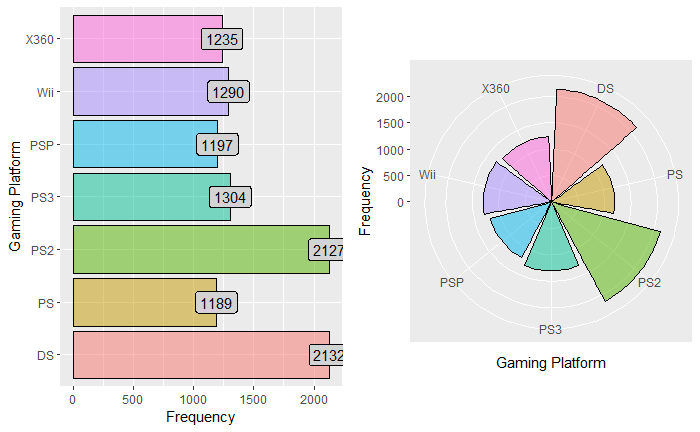

## Frequency distribution of Genre

### Here, we can say that Action and Sports are the most played Genre in the world.

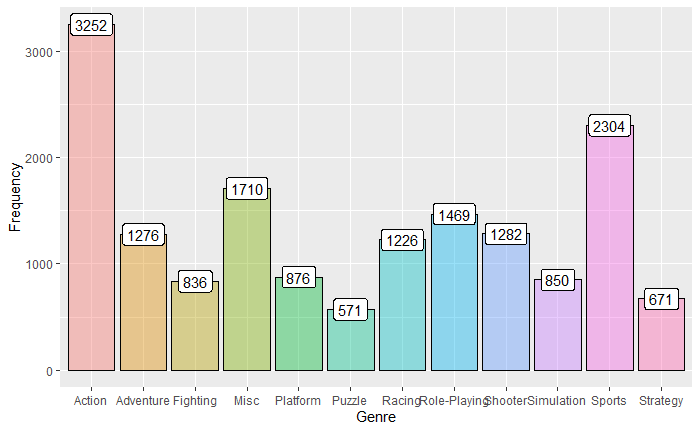

## Frequency distribution of Publisher

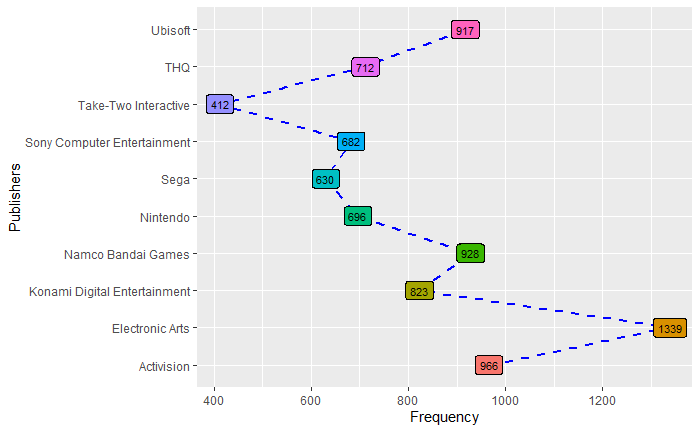

## Measure of Central Tendency

### Mean of the Sales of Games

|  | Mean |
| --- | --- |
| NA_Sales | 0.26546346 |
| EU_Sales | 0.14759052 |
| JP_Sales | 0.07867733 |
| Other_Sales | 0.04833609 |
| Global_Sales | 0.54034307 |

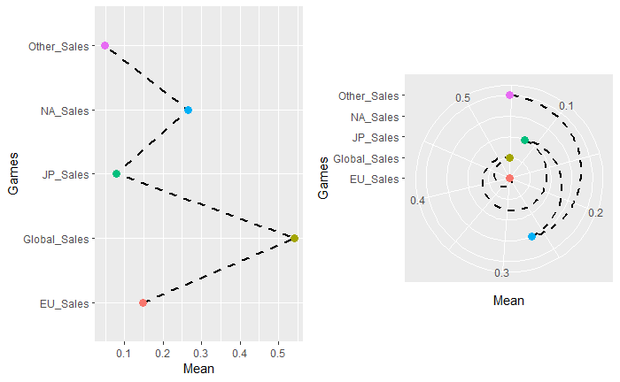

### Median of the Sales of Games

|  | Median |
| --- | --- |
| NA_Sales | 0.08 |
| EU_Sales | 0.02 |
| JP_Sales | 0.00 |
| Other_Sales | 0.01 |
| Global_Sales | 0.17 |

### Mode

|  | Mode |
| --- | --- |
| NA_Sales | 0 |
| EU_Sales | 0 |
| JP_Sales | 0 |
| Other_Sales | 0 |
| Global_Sales | 0.02 |

### All Measures of Central Tendancy together

|  | Mean | Median | Mode |
| --- | --- | --- | --- |
| NA_Sales | 0.26546346 | 0.08 | 0 |
| EU_Sales | 0.14759052 | 0.02 | 0 |
| JP_Sales | 0.07867733 | 0.00 | 0 |
| Other_Sales | 0.04833609 | 0.01 | 0 |
| Global_Sales | 0.54034307 | 0.17 | 0.02 |

## Percentile of all the Sales

|  | NA_Sales | EU_Sales | JP_Sales | Other_Sales | Global_Sales |
| --- | --- | --- | --- | --- | --- |
| 25% | 0.0000 | 0.00 | 0.00 | 0.00 | 0.0600 |
| 50% | 0.0800 | 0.02 | 0.00 | 0.01 | 0.1700 |
| 75% | 0.2400 | 0.11 | 0.04 | 0.04 | 0.4800 |
| 99% | 2.8156 | 1.94 | 1.27 | 0.65 | 5.4678 |

## Absolute Mean Deviation of all Sales

|  | ADM |
| --- | --- |
| NA_Sales | 0.30947311 |
| EU_Sales | 0.19126483 |
| JP_Sales | 0.11670815 |
| Other_Sales | 0.06172115 |
| Global_Sales | 0.59452820 |

## Variance among all the Sales

|  | Variance |
| --- | --- |
| NA_Sales | 0.67516400 |
| EU_Sales | 0.25890063 |
| JP_Sales | 0.09709044 |
| Other_Sales | 0.03606483 |
| Global_Sales | 2.45206289 |

## Standard Deviation among the Sales

|  | SDeviation |
| --- | --- |
| NA_Sales | 0.8216836 |
| EU_Sales | 0.5088228 |
| JP_Sales | 0.3115934 |
| Other_Sales | 0.1899074 |
| Global_Sales | 1.5659064 |

## Measures of Dispersion all together

|  | ADM | Variance | SDeviation |
| --- | --- | --- | --- |
| NA_Sales | 0.30947311 | 0.67516400 | 0.8216836 |
| EU_Sales | 0.19126483 | 0.25890063 | 0.5088228 |
| JP_Sales | 0.11670815 | 0.09709044 | 0.3115934 |
| Other_Sales | 0.06172115 | 0.03606483 | 0.1899074 |
| Global_Sales | 0.59452820 | 2.45206289 | 1.5659064 |

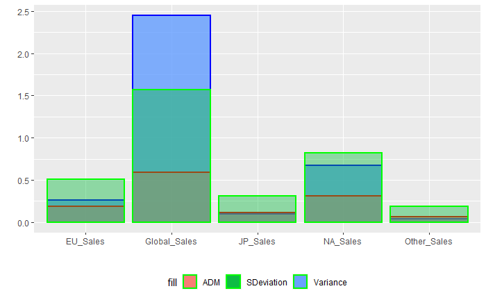

# Explorartory Data Analysis

### Top North America sales of games

#### We can say that Wii Sports is the most sold game in the North America

|  | Name | NA_Sales |
| --- | --- | --- |
| 10862 | Wii Sports | 41.49 |
| 9241 | Super Mario Bros. | 32.48 |
| 2557 | Duck Hunt | 26.93 |
| 9599 | Tetris | 26.17 |
| 3662 | Grand Theft Auto V | 23.46 |
| 1195 | Call of Duty: Black Ops | 17.01 |
| 9255 | Super Mario World | 15.99 |
| 5464 | Mario Kart Wii | 15.85 |
| 10864 | Wii Sports Resort | 15.75 |
| 1201 | Call of Duty: Modern Warfare 3 | 15.58 |

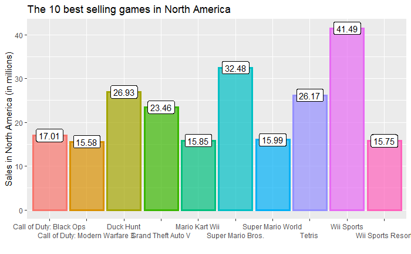

### Top Europe sales of games

#### In Europe region, Wii Sports and GTA 5 are most sold games.

|  | Name | EU_Sales |
| --- | --- | --- |
| 10862 | Wii Sports | 29.02 |
| 3662 | Grand Theft Auto V | 23.04 |
| 5464 | Mario Kart Wii | 12.88 |
| 3042 | FIFA 15 | 12.40 |
| 1201 | Call of Duty: Modern Warfare 3 | 11.29 |
| 3043 | FIFA 16 | 11.29 |
| 3041 | FIFA 14 | 11.14 |
| 1197 | Call of Duty: Black Ops II | 11.05 |
| 10864 | Wii Sports Resort | 11.01 |
| 6728 | Nintendogs | 11.00 |

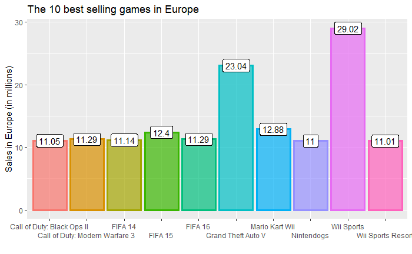

### Top Japan Sales of games

#### Pokemon Red is the most sold game in Japan.

|  | Name | JP_sales |
| --- | --- | --- |
| 7280 | Pokemon Red/Pokemon Blue | 10.22 |
| 7263 | Pokemon Gold/Pokemon Silver | 7.20 |
| 9241 | Super Mario Bros. | 6.96 |
| 6572 | New Super Mario Bros. | 6.50 |
| 7260 | Pokemon Diamond/Pokemon Pearl | 6.04 |
| 9599 | Tetris | 6.03 |
| 7252 | Pokemon Black/Pokemon White | 5.65 |
| 2460 | Dragon Quest VII: Warriors of Eden | 5.40 |
| 7281 | Pokemon Ruby/Pokemon Sapphire | 5.38 |
| 333 | Animal Crossing: Wild World | 5.33 |

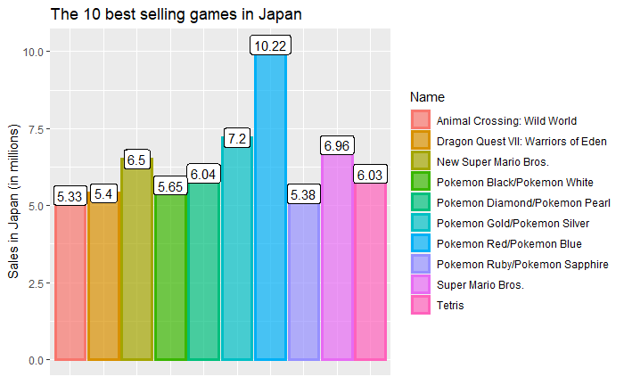

### Other Countires Sales

|  | Name | Other_Sales |
| --- | --- | --- |
| 3666 | Grand Theft Auto: San Andreas | 10.72 |
| 10862 | Wii Sports | 8.46 |
| 3662 | Grand Theft Auto V | 8.03 |
| 3644 | Gran Turismo 4 | 7.53 |
| 1197 | Call of Duty: Black Ops II | 3.88 |
| 3053 | FIFA Soccer 08 | 3.53 |
| 7439 | Pro Evolution Soccer 2008 | 3.51 |
| 1196 | Call of Duty: Black Ops 3 | 3.42 |
| 1201 | Call of Duty: Modern Warfare 3 | 3.35 |
| 5464 | Mario Kart Wii | 3.31 |

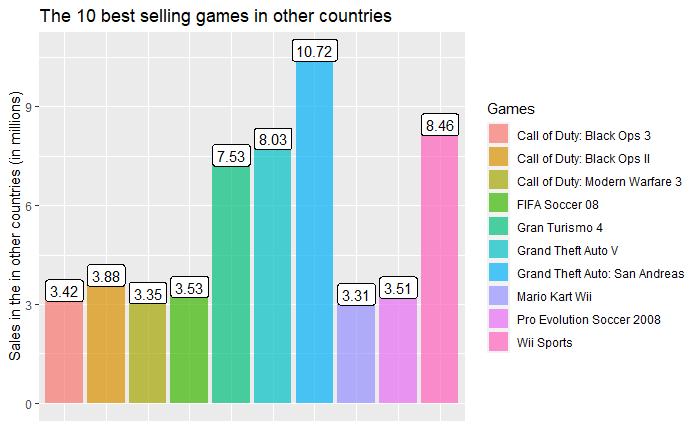

### Top Global Sales of games

#### Wii Sports is the most played game globally by people

|  | Name | Global_sales |
| --- | --- | --- |
| 10862 | Wii Sports | 82.74 |
| 3662 | Grand Theft Auto V | 55.92 |
| 9241 | Super Mario Bros. | 45.31 |
| 9599 | Tetris | 35.84 |
| 5464 | Mario Kart Wii | 35.82 |
| 10864 | Wii Sports Resort | 33.00 |
| 7280 | Pokemon Red/Pokemon Blue | 31.37 |
| 1201 | Call of Duty: Modern Warfare 3 | 30.83 |
| 6572 | New Super Mario Bros. | 30.01 |
| 1197 | Call of Duty: Black Ops II | 29.72 |

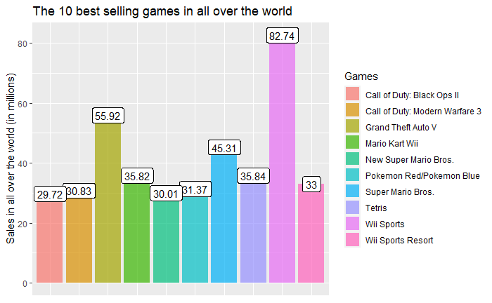

[figure not shown]

[figure not shown]

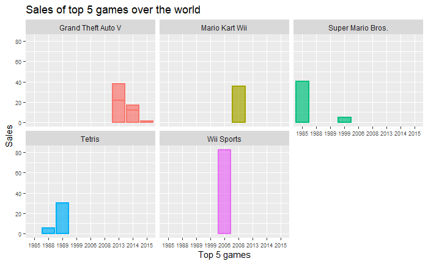

## Number of Sales per platform

### North America sales

|  | Platform | NA_sales |
| --- | --- | --- |
| 29 | X360 | 594.33 |
| 17 | PS2 | 572.92 |
| 26 | Wii | 497.37 |
| 18 | PS3 | 388.9 |
| 5 | DS | 388.29 |
| 16 | PS | 334.71 |
| 7 | GBA | 184.12 |
| 30 | XB | 182.06 |
| 11 | N64 | 138.91 |
| 8 | GC | 131.94 |

[output cut: 21 more lines]

### PS2 and Xbox360 is the most used gaming device by people.

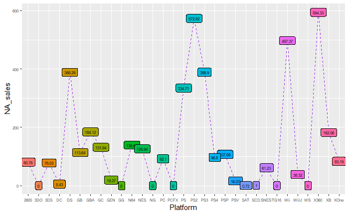

### Europe sales

|  | Platform | EU_Sales |
| --- | --- | --- |
| 18 | PS3 | 340.47 |
| 17 | PS2 | 332.63 |
| 29 | X360 | 278.01 |
| 26 | Wii | 264.35 |
| 16 | PS | 212.38 |
| 5 | DS | 194.07 |
| 14 | PC | 137.64 |
| 19 | PS4 | 123.7 |
| 7 | GBA | 74.59 |
| 20 | PSP | 67.16 |

[output cut: 21 more lines]

### PS3 and PS2 are most used gaming devices in Europe.

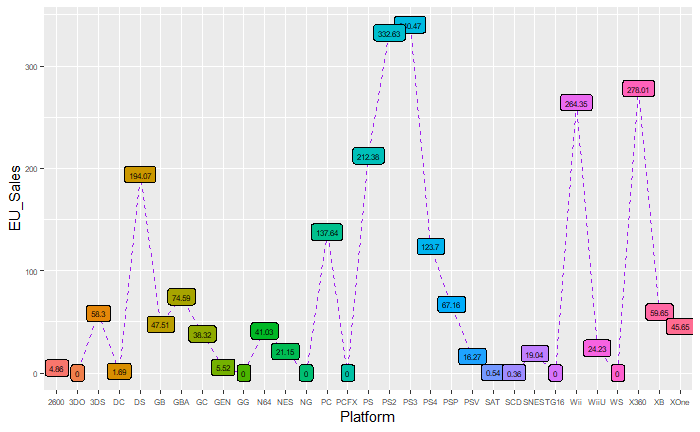

### Japan Sales

|  | Platform | JP_sales |
| --- | --- | --- |
| 5 | DS | 175.02 |
| 16 | PS | 139.78 |
| 17 | PS2 | 137.54 |
| 24 | SNES | 116.55 |
| 12 | NES | 98.65 |
| 3 | 3DS | 97.3 |
| 6 | GB | 85.12 |
| 18 | PS3 | 79.21 |
| 20 | PSP | 75.89 |
| 26 | Wii | 68.28 |

[output cut: 21 more lines]

#### Dual Screen is most used gaming device in Japan.

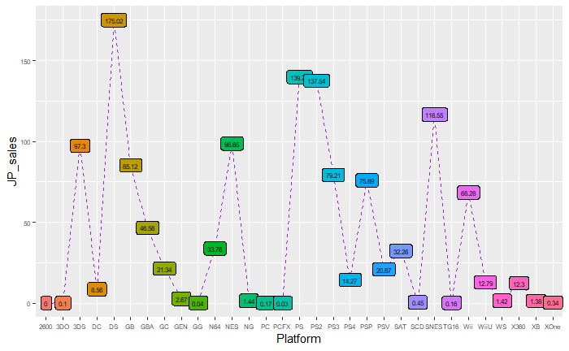

### Other Countires Sales

|  | Platform | Other_Sales |
| --- | --- | --- |
| 17 | PS2 | 190.47 |
| 18 | PS3 | 140.81 |
| 29 | X360 | 84.67 |
| 26 | Wii | 79.2 |
| 5 | DS | 60.27 |
| 19 | PS4 | 43.36 |
| 20 | PSP | 41.52 |
| 16 | PS | 40.69 |
| 14 | PC | 24.33 |
| 3 | 3DS | 12.55 |

[output cut: 21 more lines]

#### PS2 is most used gaming device in rest of th world.

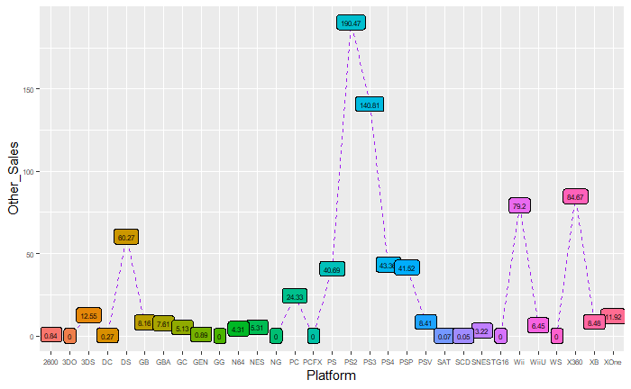

### Global Sales

#### PS2 is the most used gaming device globally.

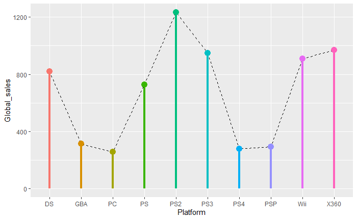

### Total Global Sales by Year

|  | Year | Global_Sales |
| --- | --- | --- |
| 1 | 1980 | 11.38 |
| 2 | 1981 | 35.77 |
| 3 | 1982 | 28.86 |
| 4 | 1983 | 16.79 |
| 5 | 1984 | 50.36 |
| 6 | 1985 | 53.94 |
| 7 | 1986 | 37.07 |
| 8 | 1987 | 21.74 |
| 9 | 1988 | 47.22 |
| 10 | 1989 | 73.45 |

[output cut: 27 more lines]

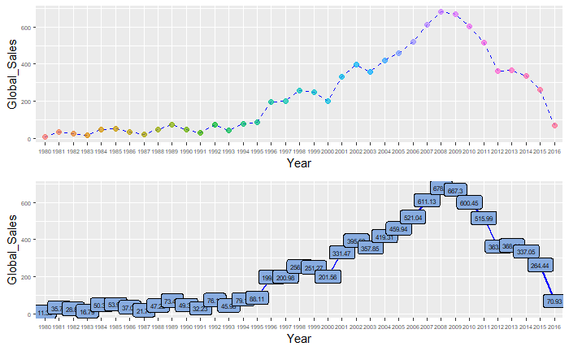

### We can conclude that, from 2007 to 2010 sales of games over the world was strong.